# social network

eric

11/09/2019

```r
head(product)
```

```
##   id                                                             title
## 1  1                           Patterns of Preaching: A Sermon Sampler
## 2  2                                        Candlemas: Feast of Flames
## 3  3                  World War II Allied Fighter Planes Trading Cards
## 4  4      Life Application Bible Commentary: 1 and 2 Timothy and Titus
## 5  5                   Prayers That Avail Much for Business: Executive
## 6  6 How the Other Half Lives: Studies Among the Tenements of New York
##   group salesrank review_cnt downloads rating
## 1  Book    396585          2         2    5.0
## 2  Book    168596         12        12    4.5
## 3  Book   1270652          1         1    5.0
## 4  Book    631289          1         1    4.0
## 5  Book    455160          0         0    0.0
## 6  Book    188784         17        17    4.0
```

```r
head(copurchase)
```

```
##   Source Target
## 1      1      2
## 2      1      4
## 3      1      5
## 4      1     15
## 5      2     11
## 6      2     12
```

Delete products that are not books from “products” and “copurchase” files. Note: In social network analysis, it important to define the boundary of your work; in other words, the boundary of the network.

```r
library(dplyr)
product_book<-filter(product, group=="Book" &
                       product$salesrank<=150000 &
                       product$salesrank !=-1)
copurchase_book<-filter(copurchase, copurchase$Source %in% product_book$id &
                         copurchase$Target %in% product_book$id)
```

```r
library(igraph)
g <- graph.data.frame(copurchase_book, directed = T)

in_degree <- degree(g, mode = 'in')
head(in_degree)
```

```
##  12  74  77  79 117 120
##   5   1   3   0   9   3
```

```r
out_degree <- degree(g, mode = 'out')
head(out_degree)
```

```
##  12  74  77  79 117 120
##   1   1   1   1   1   1
```

```r
all_degree <- degree(g, mode = 'all')
max(all_degree)
```

```
## [1] 53
```

We ran the degree function to determine how many degrees are connected to the nodes. Then, we asked R to spit out the maximum number of in and out degrees for all the nodes, to which we got 53. From there, we needed to figure out which of the nodes had 53 degrees or in other words, are connected to this particular focal product. We found out that node 4429 and node 33 both have 53 degrees.

```r
all_degree[all_degree==53]
```

```
## 4429   33
##   53   53
```

As for our subcomponent, we decided to use the node 33.

```r
sub <- subcomponent(g, "33",'all')
sub
```

```
## + 904/20684 vertices, named, from c985450:
##   [1] 33     224    577    626    2558   3909   4068   8396   8715   9487
##  [11] 10787  17360  18508  21577  27795  28536  32485  39846  58399  59222
##  [21] 60366  64566  65985  68557  72753  98134  124680 144104 147832 156667
##  [31] 158642 178420 182671 184545 187824 188486 195144 195240 198014 208329
##  [41] 209650 212464 215934 216861 219348 224446 225689 236814 245203 245307
##  [51] 245321 245894 258438 261899 193    66465  7406   94702  3861   5355
##  [61] 7325   14950  18771  26080  26373  28759  29073  38188  38486  44035
##  [71] 72034  110901 122108 143888 237935 242813 3032   5018   5821   8732
##  [81] 9299   38040  42344  59791  108623 231027 5388   79074  10365  27932
##  [91] 33868  14623  7754   26786  9355   53729  86997  77404  101859 36718
## + ... omitted several vertices
```

```r
graph <- induced_subgraph(g, sub)
graph
```

```
## IGRAPH b62ecdf DN-- 904 1173 --
## + attr: name (v/c)
## + edges from b62ecdf (vertex names):
##  [1] 77  ->422  130 ->78   148 ->302  187 ->321  187 ->322  187 ->78
##  [7] 193 ->224  224 ->193  224 ->33   321 ->187  321 ->322  321 ->78
## [13] 322 ->187  322 ->321  322 ->78   422 ->77   422 ->1644 556 ->78
## [19] 577 ->33   626 ->33   724 ->302  1051->302  1644->422  1644->5293
## [25] 1817->976  1822->193  1822->724  1851->78   1971->193  2071->3155
## [31] 2210->2279 2210->2285 2279->2210 2279->2326 2285->2330 2326->193
## [37] 2326->2210 2330->2343 2330->2345 2332->4140 2343->2285 2343->2330
## [43] 2423->5410 2470->556  2501->3588 2505->2501 2558->33   2572->4184
## + ... omitted several edges
```

```r
V(graph)
```

```
## + 904/904 vertices, named, from b62ecdf:
##   [1] 77     130    148    187    193    224    321    322    422    556
##  [11] 577    626    724    1051   1644   1817   1822   1851   1971   2071
##  [21] 2210   2279   2285   2326   2330   2332   2343   2423   2470   2501
##  [31] 2505   2558   2572   2657   2658   2806   2807   2959   3032   3119
##  [41] 3191   3217   3306   3427   3588   3670   3737   3861   3909   4002
##  [51] 4014   4038   4068   4099   4140   4174   4184   4185   4222   4223
##  [61] 4345   4429   4977   4993   4994   5018   5059   5163   5164   5293
##  [71] 5355   5388   5623   5638   5639   5655   5670   5821   5851   5875
##  [81] 6012   6014   6058   6059   6392   6411   6445   6546   6711   6713
##  [91] 6807   6808   6817   6942   7196   7198   7222   7233   7325   7376
## + ... omitted several vertices
```

```r
E(graph)
```

```
## + 1173/1173 edges from b62ecdf (vertex names):
##  [1] 77  ->422  130 ->78   148 ->302  187 ->321  187 ->322  187 ->78
##  [7] 193 ->224  224 ->193  224 ->33   321 ->187  321 ->322  321 ->78
## [13] 322 ->187  322 ->321  322 ->78   422 ->77   422 ->1644 556 ->78
## [19] 577 ->33   626 ->33   724 ->302  1051->302  1644->422  1644->5293
## [25] 1817->976  1822->193  1822->724  1851->78   1971->193  2071->3155
## [31] 2210->2279 2210->2285 2279->2210 2279->2326 2285->2330 2326->193
## [37] 2326->2210 2330->2343 2330->2345 2332->4140 2343->2285 2343->2330
## [43] 2423->5410 2470->556  2501->3588 2505->2501 2558->33   2572->4184
## [49] 2572->4185 2657->2658 2658->77   2806->2807 2807->302  2959->1673
## [55] 3032->2558 3119->976  3191->2279 3217->4319 3306->2071 3306->4345
## + ... omitted several edges
```

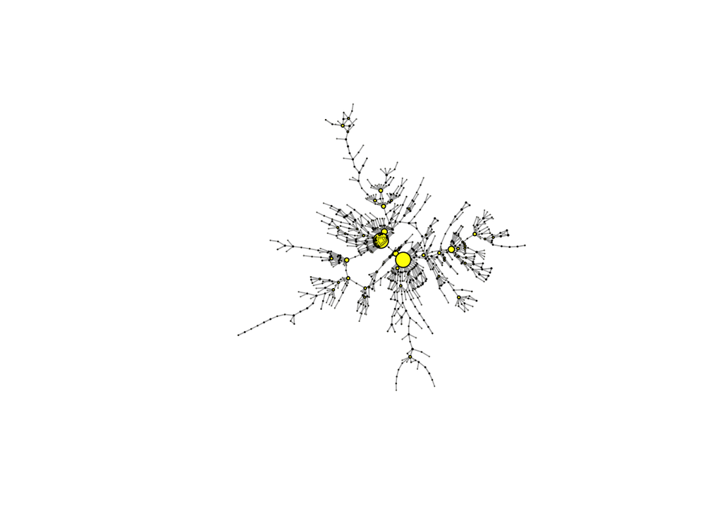

```r
V(graph)$label <- V(graph)$name
V(graph)$degree <- degree(graph)
plot(graph,
     vertex.color='yellow',
     vertex.size= V(graph)$degree*0.2,
     edge.arrow.size=0.01,
     vertex.label.cex=0.01,
     layout=layout.kamada.kawai)
```

```r
diameter(graph, directed = T, weights = NA)
```

```
## [1] 9
```